# Broom Package

David Asare Kumi

4/17/2020

## Overview

- broom summarizes key information about models in tidy tibble()s. broom provides three verbs to make it convenient to interact with model objects:
1. tidy() summarizes information about model components.
2. glance() reports information about the entire model.
3. augment() adds informations about observations to a dataset.

## Usage

- tidy() produces a tibble() where each row contains information about an important component of the model. For regression models, this often corresponds to regression coefficients. This is can be useful if you want to inspect a model or create custom visualizations.

```r
library(ggplot2)
library(dplyr)
library(tidyr)
library(gridExtra)
library(Lahman)
library(broom)
data(iris)

fit <- lm(Sepal.Width ~ Petal.Length + Petal.Width, iris)
tidy(fit)
```

```
# A tibble: 3 x 5
  term         estimate std.error statistic  p.value
  <chr>           <dbl>     <dbl>     <dbl>    <dbl>
1 (Intercept)     3.59     0.0937     38.3  2.51e-78
2 Petal.Length   -0.257    0.0669     -3.84 1.80e- 4
3 Petal.Width     0.364    0.155       2.35 2.01e- 2
```

- glance() returns a tibble with exactly one row of goodness of fitness measures and related statistics. This is useful to check for model misspecification and to compare many models.

```r
library(ggplot2)
library(dplyr)
library(tidyr)
library(gridExtra)
library(Lahman)
library(broom)
data(iris)

glance(fit)
```

```
# A tibble: 1 x 11
  r.squared adj.r.squared sigma statistic p.value    df logLik   AIC   BIC
      <dbl>         <dbl> <dbl>     <dbl>   <dbl> <int>  <dbl> <dbl> <dbl>
1     0.213         0.202 0.389      19.9 2.24e-8     3  -69.8  148.  160.
# … with 2 more variables: deviance <dbl>, df.residual <int>
```

- augment adds columns to a dataset, containing information such as fitted values, residuals or cluster assignments. All columns added to a dataset have . prefix to prevent existing columns from being overwritten.

```r
library(ggplot2)
library(dplyr)
library(tidyr)
library(gridExtra)
library(Lahman)
library(broom)
data(iris)

augment(fit, data = iris)
```

```
# A tibble: 150 x 12
   Sepal.Length Sepal.Width Petal.Length Petal.Width Species .fitted .se.fit
          <dbl>       <dbl>        <dbl>       <dbl> <fct>     <dbl>   <dbl>
 1          5.1         3.5          1.4         0.2 setosa     3.30  0.0532
 2          4.9         3            1.4         0.2 setosa     3.30  0.0532
 3          4.7         3.2          1.3         0.2 setosa     3.33  0.0547
 4          4.6         3.1          1.5         0.2 setosa     3.27  0.0526
 5          5           3.6          1.4         0.2 setosa     3.30  0.0532
 6          5.4         3.9          1.7         0.4 setosa     3.30  0.0497
 7          4.6         3.4          1.4         0.3 setosa     3.34  0.0546
 8          5           3.4          1.5         0.2 setosa     3.27  0.0526
 9          4.4         2.9          1.4         0.2 setosa     3.30  0.0532
10          4.9         3.1          1.5         0.1 setosa     3.24  0.0574
# … with 140 more rows, and 5 more variables: .resid <dbl>, .hat <dbl>,
#   .sigma <dbl>, .cooksd <dbl>, .std.resid <dbl>
```

## Example: linear regression

```r
library(ggplot2)
library(dplyr)
library(tidyr)
library(gridExtra)
library(Lahman)
library(broom)
data(mtcars)

fit <- lm(mpg ~ wt + qsec, mtcars)
summary(fit)
```

```
Call:
lm(formula = mpg ~ wt + qsec, data = mtcars)

Residuals:
    Min      1Q  Median      3Q     Max
-4.3962 -2.1431 -0.2129  1.4915  5.7486

Coefficients:
            Estimate Std. Error t value Pr(>|t|)
(Intercept)  19.7462     5.2521   3.760 0.000765 ***
wt           -5.0480     0.4840 -10.430 2.52e-11 ***
qsec          0.9292     0.2650   3.506 0.001500 **
---
Signif. codes:  0 '***' 0.001 '**' 0.01 '*' 0.05 '.' 0.1 ' ' 1

Residual standard error: 2.596 on 29 degrees of freedom
Multiple R-squared:  0.8264,    Adjusted R-squared:  0.8144
F-statistic: 69.03 on 2 and 29 DF,  p-value: 9.395e-12
```

- This summary shows many kinds of statistics describing the regression: coefficient estimates and p-values, information about the residuals, and model statistics like $R^2$ and the F statistic. But this format isn’t convenient if you want to combine and compare multiple models, or plot it using ggplot2: you need to turn it into a data frame.
- The broom package provides three tidying methods for turning the contents of this object into a data frame, depending on the level of statistics you’re interested in. If you want statistics about each of the coefficients fit by the model, use the tidy() method:

```r
library(ggplot2)
library(dplyr)
library(tidyr)
library(gridExtra)
library(Lahman)
library(broom)
data(mtcars)

tidy(fit)
```

```
# A tibble: 3 x 5
  term        estimate std.error statistic  p.value
  <chr>          <dbl>     <dbl>     <dbl>    <dbl>
1 (Intercept)   19.7       5.25       3.76 7.65e- 4
2 wt            -5.05      0.484    -10.4  2.52e-11
3 qsec           0.929     0.265      3.51 1.50e- 3
```

- Note that the rownames are now added as a column, term, meaning that the data can be combined with other models. Note also that the columns have been given names like std.error and p.value that are more easily accessed than Std. Error and Pr(>|t|). This is true of all data frames broom returns: they’re designed so they can be processed in additional steps.
- If you’re interested in extracting per-observation information, such as fitted values and residuals, use the augment() method, which adds these to the original data:

```r
library(ggplot2)
library(dplyr)
library(tidyr)
library(gridExtra)
library(Lahman)
library(broom)
data(mtcars)

head(augment(fit))
```

```
# A tibble: 6 x 11
  .rownames   mpg    wt  qsec .fitted .se.fit  .resid   .hat .sigma .cooksd
  <chr>     <dbl> <dbl> <dbl>   <dbl>   <dbl>   <dbl>  <dbl>  <dbl>   <dbl>
1 Mazda RX4  21    2.62  16.5    21.8   0.683 -0.815  0.0693   2.64 2.63e-3
2 Mazda RX…  21    2.88  17.0    21.0   0.547 -0.0482 0.0444   2.64 5.59e-6
3 Datsun 7…  22.8  2.32  18.6    25.3   0.640 -2.53   0.0607   2.60 2.17e-2
4 Hornet 4…  21.4  3.22  19.4    21.6   0.623 -0.181  0.0576   2.64 1.05e-4
5 Hornet S…  18.7  3.44  17.0    18.2   0.512  0.504  0.0389   2.64 5.29e-4
6 Valiant    18.1  3.46  20.2    21.1   0.803 -2.97   0.0957   2.58 5.10e-2
# … with 1 more variable: .std.resid <dbl>
```

- Finally, glance() computes per-model statistics, such as $R^2$, AIC, and BIC:

```r
library(ggplot2)
library(dplyr)
library(tidyr)
library(gridExtra)
library(Lahman)
library(broom)
data(mtcars)

glance(fit)
```

```
# A tibble: 1 x 11
  r.squared adj.r.squared sigma statistic  p.value    df logLik   AIC   BIC
      <dbl>         <dbl> <dbl>     <dbl>    <dbl> <int>  <dbl> <dbl> <dbl>
1     0.826         0.814  2.60      69.0 9.39e-12     3  -74.4  157.  163.
# … with 2 more variables: deviance <dbl>, df.residual <int>
```

- As pointed out by Mike Love, the tidy method makes it easy to construct coefficient plots using ggplot2:

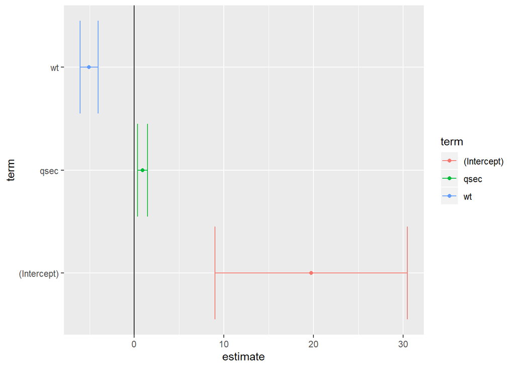

```r
library(ggplot2)
library(dplyr)
library(tidyr)
library(gridExtra)
library(Lahman)
library(broom)
data(mtcars)

td <- tidy(fit, conf.int = TRUE)
ggplot(td, aes(estimate, term, color = term)) +
    geom_point() +
    geom_errorbarh(aes(xmin = conf.low, xmax = conf.high)) +
    geom_vline(xintercept=0)
```

- When combined with dplyr’s group_by and do, broom also lets you perform regressions within groups, such as within automatic and manual cars separately:

```r
library(ggplot2)
library(dplyr)
library(tidyr)
library(gridExtra)
library(Lahman)
library(broom)
data(mtcars)

mtcars %>% group_by(am) %>% do(tidy(lm(mpg ~ wt, .)))
```

```
# A tibble: 4 x 6
# Groups:   am [2]
     am term        estimate std.error statistic       p.value
  <dbl> <chr>          <dbl>     <dbl>     <dbl>         <dbl>
1     0 (Intercept)    31.4      2.95      10.7  0.00000000601
2     0 wt             -3.79     0.767     -4.94 0.000125
3     1 (Intercept)    46.3      3.12      14.8  0.0000000128
4     1 wt             -9.08     1.26      -7.23 0.0000169
```

- This is useful for performing regressions or other analyses within each gene, country, or any other kind of division in your tidy dataset.

## Using tidiers for visualization with ggplot2

- The broom package provides tidying methods for many other packages as well. These tidiers serve to connect various statistical models seamlessly with packages like dplyr and ggplot2. For instance, we could create a LASSO regression with the glmnet package:

```r
library(ggplot2)
library(dplyr)
library(tidyr)
library(gridExtra)
library(Lahman)
library(broom)
data(mtcars)

library(glmnet)
set.seed(03-19-2015)

# generate data with 5 real variables and 45 null, on 100 observations
nobs <- 100
nvar <- 50
real <- 5
x <- matrix(rnorm(nobs * nvar), nobs)
beta <- c(rnorm(real, 0, 1), rep(0, nvar - real))
y <- c(t(beta) %*% t(x)) + rnorm(nvar, sd = 3)

glmnet_fit <- cv.glmnet(x,y)
```

- Then we tidy it with broom and plot it using ggplot2:

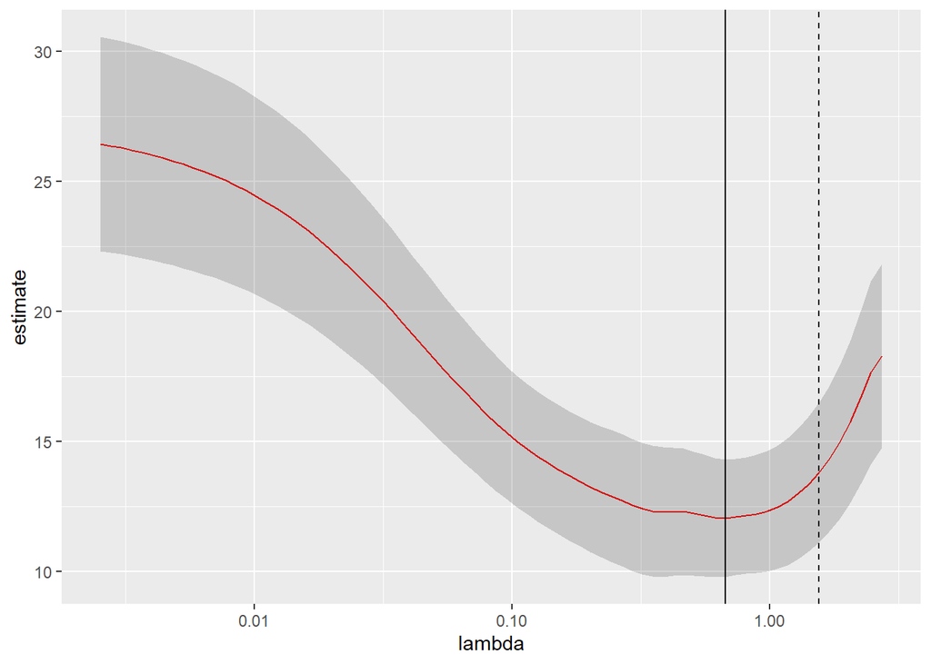

```r
library(ggplot2)
library(dplyr)
library(tidyr)
library(gridExtra)
library(Lahman)
library(broom)
data(mtcars)

library(glmnet)
set.seed(03-19-2015)

nobs <- 100
nvar <- 50
real <- 5
x <- matrix(rnorm(nobs * nvar), nobs)
beta <- c(rnorm(real, 0, 1), rep(0, nvar - real))
y <- c(t(beta) %*% t(x)) + rnorm(nvar, sd = 3)

glmnet_fit <- cv.glmnet(x,y)

tidied_cv <- tidy(glmnet_fit)
glance_cv <- glance(glmnet_fit)

ggplot(tidied_cv, aes(lambda, estimate)) + geom_line(color = "red") +
    geom_ribbon(aes(ymin = conf.low, ymax = conf.high), alpha = .2) +
    scale_x_log10() +
    geom_vline(xintercept = glance_cv$lambda.min) +
    geom_vline(xintercept = glance_cv$lambda.1se, lty = 2)
```

- By plotting with ggplot2 rather than relying on glmnet’s built-in plotting methods, we gain access to all the tools and framework of the package. This allows us to customize or add attributes, or even to compare multiple LASSO cross-validations in the same plot. The same is true of the survival package:

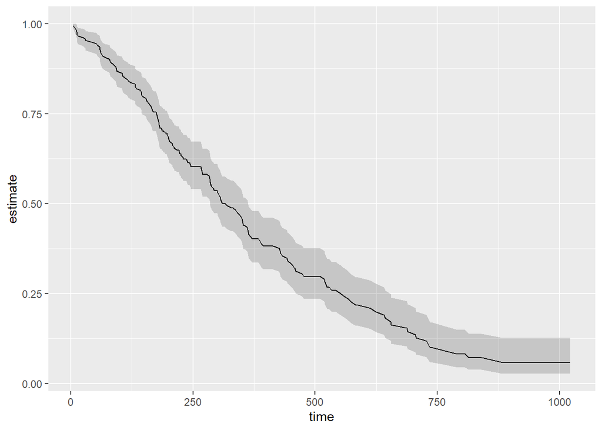

```r
library(ggplot2)
library(dplyr)
library(tidyr)
library(gridExtra)
library(Lahman)
library(broom)
data(mtcars)

library(glmnet)
set.seed(03-19-2015)

library(survival)

surv_fit <- survfit(coxph(Surv(time, status) ~ age + sex, lung))

td <- tidy(surv_fit)
ggplot(td, aes(time, estimate)) + geom_line() +
    geom_ribbon(aes(ymin = conf.low, ymax = conf.high), alpha = .2)
```

- Others have explored how broom can help visualize random effects estimated with lme4. Other packages for which tidiers are implemented include gam, zoo, lfe, and multcomp.
- The vignettes for the broom package offer other useful examples, including one on combining broom and dplyr, a demonstration of bootstrapping with broom, and a simulation of k-means clustering. The broom manuscript offers still more examples.
- Tidying model outputs is not an exact science, and it is based on a judgment of the kinds of values a data scientist typically wants out of a tidy analysis (for instance, estimates, test statistics, and p-values). It is my hope that data scientists will propose and contribute their own features feature requests are welcome!) to help expand the universe of tidy analysis tools.

## Generalized linear and non-linear models

- These functions apply equally well to the output from glm:

```r
library(ggplot2)
library(dplyr)
library(tidyr)
library(gridExtra)
library(Lahman)
library(broom)
data(mtcars)

glmfit <- glm(am ~ wt, mtcars, family="binomial")
tidy(glmfit)
```

```
# A tibble: 2 x 5
  term        estimate std.error statistic p.value
  <chr>          <dbl>     <dbl>     <dbl>   <dbl>
1 (Intercept)    12.0       4.51      2.67 0.00759
2 wt             -4.02      1.44     -2.80 0.00509
```

```r
augment(glmfit)
```

```
# A tibble: 32 x 10
   .rownames    am    wt .fitted .se.fit .resid   .hat .sigma .cooksd .std.resid
   <chr>     <dbl> <dbl>   <dbl>   <dbl>  <dbl>  <dbl>  <dbl>   <dbl>      <dbl>
 1 Mazda RX4     1  2.62   1.50    0.918  0.635 0.126   0.803 0.0184       0.680
 2 Mazda RX…     1  2.88   0.471   0.676  0.985 0.108   0.790 0.0424       1.04
 3 Datsun 7…     1  2.32   2.70    1.28   0.360 0.0963  0.810 0.00394      0.379
 4 Hornet 4…     0  3.22  -0.897   0.601 -0.827 0.0744  0.797 0.0177      -0.860
 5 Hornet S…     0  3.44  -1.80    0.749 -0.553 0.0681  0.806 0.00647     -0.572
 6 Valiant       0  3.46  -1.88    0.767 -0.532 0.0674  0.807 0.00590     -0.551
 7 Duster 3…     0  3.57  -2.33    0.878 -0.432 0.0625  0.809 0.00348     -0.446
 8 Merc 240D     0  3.19  -0.796   0.593 -0.863 0.0755  0.796 0.0199      -0.897
 9 Merc 230      0  3.15  -0.635   0.586 -0.922 0.0776  0.793 0.0242      -0.960
10 Merc 280      0  3.44  -1.80    0.749 -0.553 0.0681  0.806 0.00647     -0.572
# … with 22 more rows
```

```r
glance(glmfit)
```

```
# A tibble: 1 x 7
  null.deviance df.null logLik   AIC   BIC deviance df.residual
          <dbl>   <int>  <dbl> <dbl> <dbl>    <dbl>       <int>
1          43.2      31  -9.59  23.2  26.1     19.2          30
```

- Note that the statistics computed by glance are different for glm objects than for lm (e.g. deviance rather than R^2):
- These functions also work on other fits, such as nonlinear models (nls):

```r
library(ggplot2)
library(dplyr)
library(tidyr)
library(gridExtra)
library(Lahman)
library(broom)
data(mtcars)

nlsfit <- nls(mpg ~ k / wt + b, mtcars, start=list(k=1, b=0))
tidy(nlsfit)
```

```
# A tibble: 2 x 5
  term  estimate std.error statistic  p.value
  <chr>    <dbl>     <dbl>     <dbl>    <dbl>
1 k        45.8       4.25     10.8  7.64e-12
2 b         4.39      1.54      2.85 7.74e- 3
```

```r
augment(nlsfit,mtcars)
```

```
# A tibble: 32 x 14
   .rownames   mpg   cyl  disp    hp  drat    wt  qsec    vs    am  gear  carb
   <chr>     <dbl> <dbl> <dbl> <dbl> <dbl> <dbl> <dbl> <dbl> <dbl> <dbl> <dbl>
 1 Mazda RX4  21       6  160    110  3.9   2.62  16.5     0     1     4     4
 2 Mazda RX…  21       6  160    110  3.9   2.88  17.0     0     1     4     4
 3 Datsun 7…  22.8     4  108     93  3.85  2.32  18.6     1     1     4     1
 4 Hornet 4…  21.4     6  258    110  3.08  3.22  19.4     1     0     3     1
 5 Hornet S…  18.7     8  360    175  3.15  3.44  17.0     0     0     3     2
 6 Valiant    18.1     6  225    105  2.76  3.46  20.2     1     0     3     1
 7 Duster 3…  14.3     8  360    245  3.21  3.57  15.8     0     0     3     4
 8 Merc 240D  24.4     4  147.    62  3.69  3.19  20       1     0     4     2
 9 Merc 230   22.8     4  141.    95  3.92  3.15  22.9     1     0     4     2
10 Merc 280   19.2     6  168.   123  3.92  3.44  18.3     1     0     4     4
# … with 22 more rows, and 2 more variables: .fitted <dbl>, .resid <dbl>
```

```r
glance(nlsfit)
```

```
# A tibble: 1 x 8
  sigma isConv       finTol logLik   AIC   BIC deviance df.residual
  <dbl> <lgl>         <dbl>  <dbl> <dbl> <dbl>    <dbl>       <int>
1  2.77 TRUE   0.0000000288  -77.0  160.  164.     231.          30
```

## Hypothesis testing

- The tidy function can also be applied to htest objects, such as those output by popular built-in functions like t.test, cor.test, and wilcox.test.

```r
library(ggplot2)
library(dplyr)
library(tidyr)
library(gridExtra)
library(Lahman)
library(broom)
data(mtcars)

tt <- t.test(wt ~ am, mtcars)
tidy(tt)
```

```
# A tibble: 1 x 10
  estimate estimate1 estimate2 statistic p.value parameter conf.low conf.high
     <dbl>     <dbl>     <dbl>     <dbl>   <dbl>     <dbl>    <dbl>     <dbl>
1     1.36      3.77      2.41      5.49 6.27e-6      29.2    0.853      1.86
# … with 2 more variables: method <chr>, alternative <chr>
```

```r
#Some cases might have fewer columns (for example, no confidence interval):

wt <- wilcox.test(wt ~ am, mtcars)
tidy(wt)
```

```
# A tibble: 1 x 4
  statistic   p.value method                                         alternative
      <dbl>     <dbl> <chr>                                          <chr>
1      230. 0.0000435 Wilcoxon rank sum test with continuity correc… two.sided
```

```r
#glance
glance(tt)
```

```
# A tibble: 1 x 10
  estimate estimate1 estimate2 statistic p.value parameter conf.low conf.high
     <dbl>     <dbl>     <dbl>     <dbl>   <dbl>     <dbl>    <dbl>     <dbl>
1     1.36      3.77      2.41      5.49 6.27e-6      29.2    0.853      1.86
# … with 2 more variables: method <chr>, alternative <chr>
```

```r
glance(wt)
```

```
# A tibble: 1 x 4
  statistic   p.value method                                         alternative
      <dbl>     <dbl> <chr>                                          <chr>
1      230. 0.0000435 Wilcoxon rank sum test with continuity correc… two.sided
```

- augment method is defined only for chi-squared tests, since there is no meaningful sense, for other tests, in which a hypothesis test produces output about each initial data point.

```r
library(ggplot2)
library(dplyr)
library(tidyr)
library(gridExtra)
library(Lahman)
library(broom)
data(mtcars)

chit <- chisq.test(xtabs(Freq ~ Sex + Class, data = as.data.frame(Titanic)))
tidy(chit)
```

```
# A tibble: 1 x 4
  statistic  p.value parameter method
      <dbl>    <dbl>     <int> <chr>
1      350. 1.56e-75         3 Pearson's Chi-squared test
```

```r
augment(chit)
```

```
# A tibble: 8 x 9
  Sex    Class .observed  .prop .row.prop .col.prop .expected .residuals .stdres
  <fct>  <fct>     <dbl>  <dbl>     <dbl>     <dbl>     <dbl>      <dbl>   <dbl>
1 Male   1st         180 0.0818    0.104     0.554      256.       -4.73  -11.1
2 Female 1st         145 0.0659    0.309     0.446       69.4       9.07   11.1
3 Male   2nd         179 0.0813    0.103     0.628      224.       -3.02   -6.99
4 Female 2nd         106 0.0482    0.226     0.372       60.9       5.79    6.99
5 Male   3rd         510 0.232     0.295     0.722      555.       -1.92   -5.04
6 Female 3rd         196 0.0891    0.417     0.278      151.        3.68    5.04
7 Male   Crew        862 0.392     0.498     0.974      696.        6.29   17.6
8 Female Crew         23 0.0104    0.0489    0.0260     189.      -12.1   -17.6
```

```r
glance(chit)
```

```
# A tibble: 1 x 4
  statistic  p.value parameter method
      <dbl>    <dbl>     <int> <chr>
1      350. 1.56e-75         3 Pearson's Chi-squared test
```

## Conventions

- In order to maintain consistency, we attempt to follow some conventions regarding the structure of returned data.

## All functions

- The output of the tidy, augment and glance functions is always a data frame.
- The output never has rownames. This ensures that you can combine it with other tidy outputs without fear of losing information (since rownames in R cannot contain duplicates).
- Some column names are kept consistent, so that they can be combined across different models and so that you know what to expect (in contrast to asking “is it pval or PValue?” every time). The examples below are not all the possible column names, nor will all tidy output contain all or even any of these columns.

## tidy functions

- Each row in a tidy output typically represents some well-defined concept, such as one term in a regression, one test, or one cluster/class. This meaning varies across models but is usually self-evident. The one thing each row cannot represent is a point in the initial data (for that, use the augment method).
- Common column names include:
1. term"" the term in a regression or model that is being estimated.
2. p.value: this spelling was chosen (over common alternatives such as pvalue, PValue, or pval) to be consistent with functions in R’s built-in stats package

3.statistic a test statistic, usually the one used to compute the p-value. Combining these across many sub-groups is a reliable way to perform (e.g.) bootstrap hypothesis testing

4. estimate
5. conf.low the low end of a confidence interval on the estimate.
6. conf.high the high end of a confidence interval on the estimate.
7. df degrees of freedom.

## augment functions

- augment(model, data) adds columns to the original data.
- If the data argument is missing, augment attempts to reconstruct the data from the model (note that this may not always be possible, and usually won’t contain columns not used in the model).
- Each row in an augment output matches the corresponding row in the original data.
- If the original data contained rownames, augment turns them into a column called .rownames.
- Newly added column names begin with . to avoid overwriting columns in the original data.
- Common column names include:
- .fitted: the predicted values, on the same scale as the data.
- .resid: residuals: the actual y values minus the fitted values.
- .cluster: cluster assignments.

## glance functions

- glance always returns a one-row data frame.
- The only exception is that glance(NULL) returns an empty data frame.
- We avoid including arguments that were given to the modeling function. For example, a glm glance output does not need to contain a field for family, since that is decided by the user calling glm rather than the modeling function itself.
- Common column names include:
- r.squared the fraction of variance explained by the model.
- adj.r.squared R^2 adjusted based on the degrees of freedom.
- sigma the square root of the estimated variance of the residuals.

## broom and dplyr

- While broom is useful for summarizing the result of a single analysis in a consistent format, it is really designed for high-throughput applications, where you must combine results from multiple analyses. These could be subgroups of data, analyses using different models, bootstrap replicates, permutations, and so on. In particular, it plays well with the nest/unnest functions in tidyr and the map function in purrr.
- Let’s try this on a simple dataset, the built-in Orange. We start by coercing Orange to a tibble. This gives a nicer print method that will especially useful later on when we start working with list-columns.

```r
library(ggplot2)
library(dplyr)
library(tidyr)
library(gridExtra)
library(Lahman)
library(broom)
library(tibble)
data(mtcars)
data(Orange)

Orange <- as_tibble(Orange)
Orange
```

```
# A tibble: 35 x 3
   Tree    age circumference
   <ord> <dbl>         <dbl>
 1 1       118            30
 2 1       484            58
 3 1       664            87
 4 1      1004           115
 5 1      1231           120
 6 1      1372           142
 7 1      1582           145
 8 2       118            33
 9 2       484            69
10 2       664           111
# … with 25 more rows
```

- This contains 35 observations of three variables: Tree, age, and circumference. Tree is a factor with five levels describing five trees. As might be expected, age and circumference are correlated:

```r
library(ggplot2)
library(dplyr)
library(tidyr)
library(gridExtra)
library(Lahman)
library(broom)
library(tibble)
data(mtcars)
data(Orange)

cor(Orange$age,Orange$circumference)
```

```
[1] 0.9135189
```

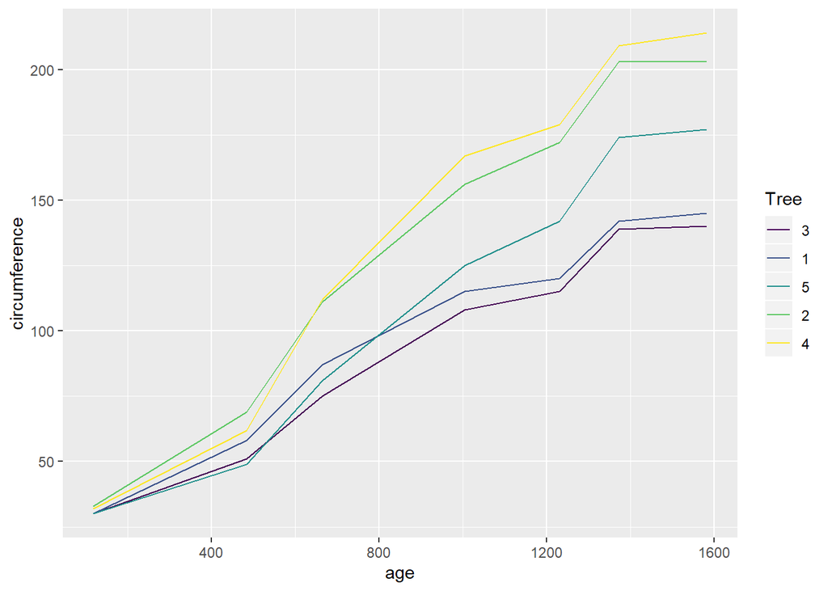

```r
ggplot(Orange, aes(age, circumference, color = Tree)) +
  geom_line()
```

- Suppose you want to test for correlations individually within each tree. You can do this with dplyr’s group_by:

```r
library(ggplot2)
library(dplyr)
library(tidyr)
library(gridExtra)
library(Lahman)
library(broom)
library(tibble)
data(mtcars)
data(Orange)

Orange %>%
  group_by(Tree) %>%
  summarize(correlation = cor(age, circumference))
```

```
# A tibble: 5 x 2
  Tree  correlation
  <ord>       <dbl>
1 3           0.988
2 1           0.985
3 5           0.988
4 2           0.987
5 4           0.984
```

- (Note that the correlations are much higher than the aggregated one, and furthermore we can now see it is similar across trees).
- Suppose that instead of simply estimating a correlation, we want to perform a hypothesis test with cor.test:

```r
library(ggplot2)
library(dplyr)
library(tidyr)
library(gridExtra)
library(Lahman)
library(broom)
library(tibble)
data(mtcars)
data(Orange)

ct <- cor.test(Orange$age, Orange$circumference)
ct
```

```
    Pearson's product-moment correlation

data:  Orange$age and Orange$circumference
t = 12.9, df = 33, p-value = 1.931e-14
alternative hypothesis: true correlation is not equal to 0
95 percent confidence interval:
 0.8342364 0.9557955
sample estimates:
      cor
0.9135189
```

- This contains multiple values we could want in our output. Some are vectors of length 1, such as the p-value and the estimate, and some are longer, such as the confidence interval. We can get this into a nicely organized tibble using the tidy function:

```r
library(ggplot2)
library(dplyr)
library(tidyr)
library(gridExtra)
library(Lahman)
library(broom)
library(tibble)
data(mtcars)
data(Orange)

tidy(ct)
```

```
# A tibble: 1 x 8
  estimate statistic  p.value parameter conf.low conf.high method    alternative
     <dbl>     <dbl>    <dbl>     <int>    <dbl>     <dbl> <chr>     <chr>
1    0.914      12.9 1.93e-14        33    0.834     0.956 Pearson'… two.sided
```

- Often, we want to perform multiple tests or fit multiple models, each on a different part of the data. In this case, we recommend a nest-map-unnest workflow. For example, suppose we want to perform correlation tests for each different tree. We start by nesting our data based on the group of interest:

```r
library(ggplot2)
library(dplyr)
library(tidyr)
library(gridExtra)
library(Lahman)
library(broom)
library(tibble)
library(purrr)
data(mtcars)
data(Orange)

nested <- Orange %>%
  nest(-Tree)
```

- Then we run a correlation test for each nested tibble using purrr::map:

```r
library(ggplot2)
library(dplyr)
library(tidyr)
library(gridExtra)
library(Lahman)
library(broom)
library(tibble)
library(purrr)
data(mtcars)
data(Orange)

nested %>%
  mutate(test = map(data, ~ cor.test(.x$age, .x$circumference)))
```

```
  ...1                                                                   data
1    1  118, 484, 664, 1004, 1231, 1372, 1582, 30, 58, 87, 115, 120, 142, 145
2    2 118, 484, 664, 1004, 1231, 1372, 1582, 33, 69, 111, 156, 172, 203, 203
3    3  118, 484, 664, 1004, 1231, 1372, 1582, 30, 51, 75, 108, 115, 139, 140
4    4 118, 484, 664, 1004, 1231, 1372, 1582, 32, 62, 112, 167, 179, 209, 214
5    5  118, 484, 664, 1004, 1231, 1372, 1582, 30, 49, 81, 125, 142, 174, 177
                                                                                                                                                                                 test
1 12.9725812675022, 5, 4.85190172612042e-05, 0.985467542479218, 0, two.sided, Pearson's product-moment correlation, .x$age and .x$circumference, 0.901211098892195, 0.997940047627465
2  13.9312907259483, 5, 3.4250411756383e-05, 0.987362434576892, 0, two.sided, Pearson's product-moment correlation, .x$age and .x$circumference, 0.913614217291609, 0.998210111616148
3 14.4118806470308, 5, 2.90104593668442e-05, 0.988176587128534, 0, two.sided, Pearson's product-moment correlation, .x$age and .x$circumference, 0.918985789863646, 0.998326010621017
4   12.535748367901, 5, 5.73308969016429e-05, 0.984460969608121, 0, two.sided, Pearson's product-moment correlation, .x$age and .x$circumference, 0.894678180911149, 0.99779640874921
5  14.1468609718478, 5, 3.17709260945252e-05, 0.987737642291551, 0, two.sided, Pearson's product-moment correlation, .x$age and .x$circumference, 0.916086548636104, 0.99826353458178
```

- This results in a list-column of S3 objects. We want to tidy each of the objects, which we can also do with map.

```r
library(ggplot2)
library(dplyr)
library(tidyr)
library(gridExtra)
library(Lahman)
library(broom)
library(tibble)
library(purrr)
data(mtcars)
data(Orange)

nested %>%
  mutate(
    test = map(data, ~ cor.test(.x$age, .x$circumference)), # S3 list-col
    tidied = map(test, tidy)
  )
```

```
  ...1                                                                   data
1    1  118, 484, 664, 1004, 1231, 1372, 1582, 30, 58, 87, 115, 120, 142, 145
2    2 118, 484, 664, 1004, 1231, 1372, 1582, 33, 69, 111, 156, 172, 203, 203
3    3  118, 484, 664, 1004, 1231, 1372, 1582, 30, 51, 75, 108, 115, 139, 140
4    4 118, 484, 664, 1004, 1231, 1372, 1582, 32, 62, 112, 167, 179, 209, 214
5    5  118, 484, 664, 1004, 1231, 1372, 1582, 30, 49, 81, 125, 142, 174, 177
                                                                                                                                                                                 test
1 12.9725812675022, 5, 4.85190172612042e-05, 0.985467542479218, 0, two.sided, Pearson's product-moment correlation, .x$age and .x$circumference, 0.901211098892195, 0.997940047627465
2  13.9312907259483, 5, 3.4250411756383e-05, 0.987362434576892, 0, two.sided, Pearson's product-moment correlation, .x$age and .x$circumference, 0.913614217291609, 0.998210111616148
3 14.4118806470308, 5, 2.90104593668442e-05, 0.988176587128534, 0, two.sided, Pearson's product-moment correlation, .x$age and .x$circumference, 0.918985789863646, 0.998326010621017
4   12.535748367901, 5, 5.73308969016429e-05, 0.984460969608121, 0, two.sided, Pearson's product-moment correlation, .x$age and .x$circumference, 0.894678180911149, 0.99779640874921
5  14.1468609718478, 5, 3.17709260945252e-05, 0.987737642291551, 0, two.sided, Pearson's product-moment correlation, .x$age and .x$circumference, 0.916086548636104, 0.99826353458178
                                                                                                                                               tidied
1 0.985467542479218, 12.9725812675022, 4.85190172612042e-05, 5, 0.901211098892195, 0.997940047627465, Pearson's product-moment correlation, two.sided
2  0.987362434576892, 13.9312907259483, 3.4250411756383e-05, 5, 0.913614217291609, 0.998210111616148, Pearson's product-moment correlation, two.sided
3 0.988176587128534, 14.4118806470308, 2.90104593668442e-05, 5, 0.918985789863646, 0.998326010621017, Pearson's product-moment correlation, two.sided
4   0.984460969608121, 12.535748367901, 5.73308969016429e-05, 5, 0.894678180911149, 0.99779640874921, Pearson's product-moment correlation, two.sided
5  0.987737642291551, 14.1468609718478, 3.17709260945252e-05, 5, 0.916086548636104, 0.99826353458178, Pearson's product-moment correlation, two.sided
```

- Finally, we want to unnest the tidied data frames so we can see the results in a flat tibble. All together, this looks like:

```r
library(ggplot2)
library(dplyr)
library(tidyr)
library(gridExtra)
library(Lahman)
library(broom)
library(tibble)
library(purrr)
data(mtcars)
data(Orange)

Orange %>%
  nest(-Tree) %>%
  mutate(
    test = map(data, ~ cor.test(.x$age, .x$circumference)), # S3 list-col
    tidied = map(test, tidy)
  ) %>%
  unnest(tidied, .drop = TRUE)
```

```
# A tibble: 5 x 11
  ...1     data test  estimate statistic p.value parameter conf.low conf.high
  <ord> <list<> <lis>    <dbl>     <dbl>   <dbl>     <int>    <dbl>     <dbl>
1 1     [7 × 2] <hte…    0.985      13.0 4.85e-5         5    0.901     0.998
2 2     [7 × 2] <hte…    0.987      13.9 3.43e-5         5    0.914     0.998
3 3     [7 × 2] <hte…    0.988      14.4 2.90e-5         5    0.919     0.998
4 4     [7 × 2] <hte…    0.984      12.5 5.73e-5         5    0.895     0.998
5 5     [7 × 2] <hte…    0.988      14.1 3.18e-5         5    0.916     0.998
# … with 2 more variables: method <chr>, alternative <chr>
```

- Note that the .drop argument to tidyr::unnest is often useful.
- This workflow becomes even more useful when applied to regressions. Untidy ouput for a regression looks like:

```r
library(ggplot2)
library(dplyr)
library(tidyr)
library(gridExtra)
library(Lahman)
library(broom)
library(tibble)
library(purrr)
data(mtcars)
data(Orange)

lm_fit <- lm(age ~ circumference, data = Orange)
summary(lm_fit)
```

```
Call:
lm(formula = age ~ circumference, data = Orange)

Residuals:
    Min      1Q  Median      3Q     Max
-317.88 -140.90  -17.20   96.54  471.16

Coefficients:
              Estimate Std. Error t value Pr(>|t|)
(Intercept)    16.6036    78.1406   0.212    0.833
circumference   7.8160     0.6059  12.900 1.93e-14 ***
---
Signif. codes:  0 '***' 0.001 '**' 0.01 '*' 0.05 '.' 0.1 ' ' 1

Residual standard error: 203.1 on 33 degrees of freedom
Multiple R-squared:  0.8345,    Adjusted R-squared:  0.8295
F-statistic: 166.4 on 1 and 33 DF,  p-value: 1.931e-14
```

- where we tidy these results, we get multiple rows of output for each model:

```r
library(ggplot2)
library(dplyr)
library(tidyr)
library(gridExtra)
library(Lahman)
library(broom)
library(tibble)
library(purrr)
data(mtcars)
data(Orange)

tidy(lm_fit)
```

```
# A tibble: 2 x 5
  term          estimate std.error statistic  p.value
  <chr>            <dbl>     <dbl>     <dbl>    <dbl>
1 (Intercept)      16.6     78.1       0.212 8.33e- 1
2 circumference     7.82     0.606    12.9   1.93e-14
```

- Now we can handle multiple regressions at once using exactly the same workflow as before:

```r
library(ggplot2)
library(dplyr)
library(tidyr)
library(gridExtra)
library(Lahman)
library(broom)
library(tibble)
library(purrr)
data(mtcars)
data(Orange)

Orange %>%
  nest(-Tree) %>%
  mutate(
    fit = map(data, ~ lm(age ~ circumference, data = .x)),
    tidied = map(fit, tidy)
  ) %>%
  unnest(tidied)
```

```
# A tibble: 10 x 8
   ...1           data fit    term         estimate std.error statistic  p.value
   <ord> <list<df[,2]> <list> <chr>           <dbl>     <dbl>     <dbl>    <dbl>
 1 1           [7 × 2] <lm>   (Intercept)   -265.      98.6      -2.68   4.36e-2
 2 1           [7 × 2] <lm>   circumferen…    11.9      0.919    13.0    4.85e-5
 3 2           [7 × 2] <lm>   (Intercept)   -132.      83.1      -1.59   1.72e-1
 4 2           [7 × 2] <lm>   circumferen…     7.80     0.560    13.9    3.43e-5
 5 3           [7 × 2] <lm>   (Intercept)   -210.      85.3      -2.46   5.74e-2
 6 3           [7 × 2] <lm>   circumferen…    12.0      0.835    14.4    2.90e-5
 7 4           [7 × 2] <lm>   (Intercept)    -76.5     88.3      -0.867  4.26e-1
 8 4           [7 × 2] <lm>   circumferen…     7.17     0.572    12.5    5.73e-5
 9 5           [7 × 2] <lm>   (Intercept)    -54.5     76.9      -0.709  5.10e-1
10 5           [7 × 2] <lm>   circumferen…     8.79     0.621    14.1    3.18e-5
```

- You can just as easily use multiple predictors in the regressions, as shown here on the mtcars dataset. We nest the data into automatic and manual cars (the am column), then perform the regression within each nested tibble.

```r
library(ggplot2)
library(dplyr)
library(tidyr)
library(gridExtra)
library(Lahman)
library(broom)
library(tibble)
library(purrr)
data(mtcars)
data(Orange)

data(mtcars)
mtcars <- as_tibble(mtcars)  # to play nicely with list-cols
mtcars
```

```
# A tibble: 32 x 11
     mpg   cyl  disp    hp  drat    wt  qsec    vs    am  gear  carb
   <dbl> <dbl> <dbl> <dbl> <dbl> <dbl> <dbl> <dbl> <dbl> <dbl> <dbl>
 1  21       6  160    110  3.9   2.62  16.5     0     1     4     4
 2  21       6  160    110  3.9   2.88  17.0     0     1     4     4
 3  22.8     4  108     93  3.85  2.32  18.6     1     1     4     1
 4  21.4     6  258    110  3.08  3.22  19.4     1     0     3     1
 5  18.7     8  360    175  3.15  3.44  17.0     0     0     3     2
 6  18.1     6  225    105  2.76  3.46  20.2     1     0     3     1
 7  14.3     8  360    245  3.21  3.57  15.8     0     0     3     4
 8  24.4     4  147.    62  3.69  3.19  20       1     0     4     2
 9  22.8     4  141.    95  3.92  3.15  22.9     1     0     4     2
10  19.2     6  168.   123  3.92  3.44  18.3     1     0     4     4
# … with 22 more rows
```

```r
mtcars %>%
  nest(-am) %>%
  mutate(
    fit = map(data, ~ lm(wt ~ mpg + qsec + gear, data = .x)),  # S3 list-col
    tidied = map(fit, tidy)
  ) %>%
  unnest(tidied)
```

```
# A tibble: 8 x 8
     am            data fit    term        estimate std.error statistic  p.value
  <dbl> <list<df[,10]>> <list> <chr>          <dbl>     <dbl>     <dbl>    <dbl>
1     1       [13 × 10] <lm>   (Intercept)   4.28      3.46      1.24   0.247
2     1       [13 × 10] <lm>   mpg          -0.101     0.0294   -3.43   0.00750
3     1       [13 × 10] <lm>   qsec          0.0398    0.151     0.264  0.798
4     1       [13 × 10] <lm>   gear         -0.0229    0.349    -0.0656 0.949
5     0       [19 × 10] <lm>   (Intercept)   4.92      1.40      3.52   0.00309
6     0       [19 × 10] <lm>   mpg          -0.192     0.0443   -4.33   0.000591
7     0       [19 × 10] <lm>   qsec          0.0919    0.0983    0.935  0.365
8     0       [19 × 10] <lm>   gear          0.147     0.368     0.398  0.696
```

- What if you want not just the tidy output, but the augment and glance outputs as well, while still performing each regression only once? Since we’re using list-columns, we can just fit the model once and use multiple list-columns to store the tidied, glanced and augmented outputs.

```r
library(ggplot2)
library(dplyr)
library(tidyr)
library(gridExtra)
library(Lahman)
library(broom)
library(tibble)
library(purrr)
data(mtcars)
data(Orange)

regressions <- mtcars %>%
  nest(-am) %>%
  mutate(
    fit = map(data, ~ lm(wt ~ mpg + qsec + gear, data = .x)),
    tidied = map(fit, tidy),
    glanced = map(fit, glance),
    augmented = map(fit, augment)
  )

regressions %>%
  unnest(tidied)
```

```
# A tibble: 8 x 10
     am      data fit   term  estimate std.error statistic p.value glanced
  <dbl> <list<df> <lis> <chr>    <dbl>     <dbl>     <dbl>   <dbl> <list>
1     1 [13 × 10] <lm>  (Int…   4.28      3.46      1.24   2.47e-1 <tibbl…
2     1 [13 × 10] <lm>  mpg    -0.101     0.0294   -3.43   7.50e-3 <tibbl…
3     1 [13 × 10] <lm>  qsec    0.0398    0.151     0.264  7.98e-1 <tibbl…
4     1 [13 × 10] <lm>  gear   -0.0229    0.349    -0.0656 9.49e-1 <tibbl…
5     0 [19 × 10] <lm>  (Int…   4.92      1.40      3.52   3.09e-3 <tibbl…
6     0 [19 × 10] <lm>  mpg    -0.192     0.0443   -4.33   5.91e-4 <tibbl…
7     0 [19 × 10] <lm>  qsec    0.0919    0.0983    0.935  3.65e-1 <tibbl…
8     0 [19 × 10] <lm>  gear    0.147     0.368     0.398  6.96e-1 <tibbl…
# … with 1 more variable: augmented <list>
```

```r
regressions %>%
  unnest(glanced,.drop=TRUE)
```

```
# A tibble: 2 x 16
     am      data fit   tidied r.squared adj.r.squared sigma statistic p.value
  <dbl> <list<df> <lis> <list>     <dbl>         <dbl> <dbl>     <dbl>   <dbl>
1     1 [13 × 10] <lm>  <tibb…     0.833         0.778 0.291     15.0  7.59e-4
2     0 [19 × 10] <lm>  <tibb…     0.625         0.550 0.522      8.32 1.70e-3
# … with 7 more variables: df <int>, logLik <dbl>, AIC <dbl>, BIC <dbl>,
#   deviance <dbl>, df.residual <int>, augmented <list>
```

```r
regressions %>%
  unnest(augmented)
```

```
# A tibble: 32 x 16
      am      data fit   tidied glanced    wt   mpg  qsec  gear .fitted .se.fit
   <dbl> <list<df> <lis> <list> <list>  <dbl> <dbl> <dbl> <dbl>   <dbl>   <dbl>
 1     1 [13 × 10] <lm>  <tibb… <tibbl…  2.62  21    16.5     4    2.73   0.209
 2     1 [13 × 10] <lm>  <tibb… <tibbl…  2.88  21    17.0     4    2.75   0.152
 3     1 [13 × 10] <lm>  <tibb… <tibbl…  2.32  22.8  18.6     4    2.63   0.163
 4     1 [13 × 10] <lm>  <tibb… <tibbl…  2.2   32.4  19.5     4    1.70   0.137
 5     1 [13 × 10] <lm>  <tibb… <tibbl…  1.62  30.4  18.5     4    1.86   0.151
 6     1 [13 × 10] <lm>  <tibb… <tibbl…  1.84  33.9  19.9     4    1.56   0.156
 7     1 [13 × 10] <lm>  <tibb… <tibbl…  1.94  27.3  18.9     4    2.19   0.113
 8     1 [13 × 10] <lm>  <tibb… <tibbl…  2.14  26    16.7     5    2.21   0.153
 9     1 [13 × 10] <lm>  <tibb… <tibbl…  1.51  30.4  16.9     5    1.77   0.191
10     1 [13 × 10] <lm>  <tibb… <tibbl…  3.17  15.8  14.5     5    3.15   0.157
# … with 22 more rows, and 5 more variables: .resid <dbl>, .hat <dbl>,
#   .sigma <dbl>, .cooksd <dbl>, .std.resid <dbl>
```

- By combining the estimates and p-values across all groups into the same tidy data frame (instead of a list of output model objects), a new class of analyses and visualizations becomes straightforward. This includes
1. Sorting by p-value or estimate to find the most significant terms across all tests.
2. P-value histograms.
3. Volcano plots comparing p-values to effect size estimates.
- In each of these cases, we can easily filter, facet, or distinguish based on the term column. In short, this makes the tools of tidy data analysis available for the results of data analysis and models, not just the inputs.